# Sampling bias in radiocarbon dating project: broad approach 1 using the AustArch database

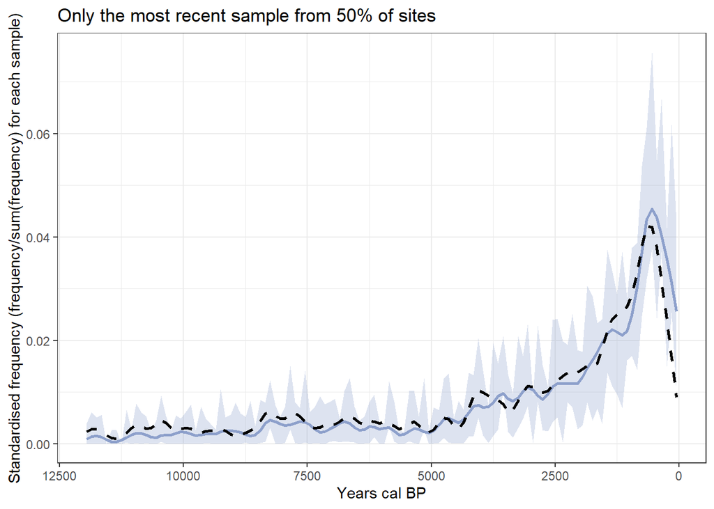

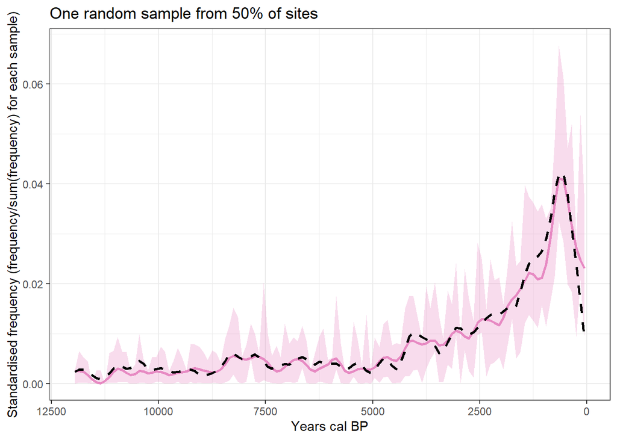

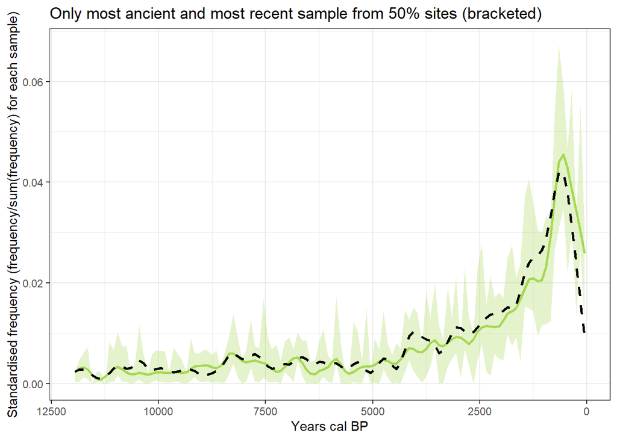

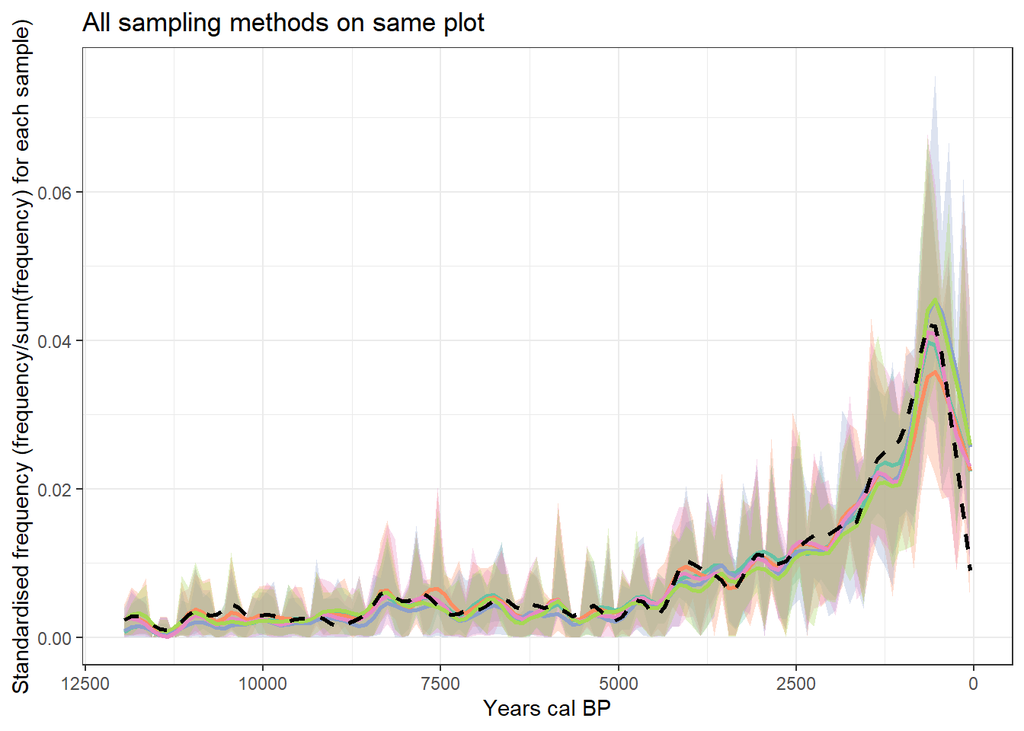

### Frequency distributions of sites with dates within time bins

Calculate the frequency distribution for each sample, and then compare the mean frequency distribution over the samples to the baseline frequency distribution:

```r
taphCorrect = FALSE    ## whether to taphonomically correct the open sites - not currently as haven't specified whether sites are open
correctForSite = TRUE  ## per bin: number of sites with at least one date in them, or number of dates within the bin total
binSize = 100          ## the size of the bins to use (years) - use a bin size that actually fits the timeRange specified

# Get median bin age for x axis (same for all plots)
median.bin.age   <- seq(timeRange[2] + binSize/2, timeRange[1] - binSize/2, by = binSize)

fd.uniform.sites           <- compare_frequency_dists(evidence = baseline.data,
                                                      samples = sample.uniform,
                                                      calibrated_evidence = cal.baseline.data,
                                                      calibrated_samples = cal.uniform,
                                                      timeRange = timeRange,
                                                      taphCorrect = taphCorrect,
                                                      correctForSite = correctForSite,
                                                      binSize = binSize)

fd.singleton.ancient.sites <- compare_frequency_dists(evidence = baseline.data,
                                                      samples = sample.singleton.ancient,
                                                      calibrated_evidence = cal.baseline.data,
                                                      calibrated_samples = cal.singleton.ancient,
                                                      timeRange = timeRange,
                                                      taphCorrect = taphCorrect,
                                                      correctForSite = correctForSite,
                                                      binSize = binSize)

fd.singleton.recent.sites  <- compare_frequency_dists(evidence = baseline.data,
                                                      samples = sample.singleton.recent,
                                                      calibrated_evidence = cal.baseline.data,
                                                      calibrated_samples = cal.singleton.recent,
                                                      timeRange = timeRange,
                                                      taphCorrect = taphCorrect,
                                                      correctForSite = correctForSite,
                                                      binSize = binSize)

fd.singleton.random.sites  <- compare_frequency_dists(evidence = baseline.data,
                                                      samples = sample.singleton.random,
                                                      calibrated_evidence = cal.baseline.data,
                                                      calibrated_samples = cal.singleton.random,
                                                      timeRange = timeRange,
                                                      taphCorrect = taphCorrect,
                                                      correctForSite = correctForSite,
                                                      binSize = binSize)

fd.bracketed.sites         <- compare_frequency_dists(evidence = baseline.data,
                                                      samples = sample.bracketed,
                                                      calibrated_evidence = cal.baseline.data,
                                                      calibrated_samples = cal.bracketed,
                                                      timeRange = timeRange,
                                                      taphCorrect = taphCorrect,
                                                      correctForSite = correctForSite,
                                                      binSize = binSize)
```

Plot the resulting frequency distributions:  
* dashed black line is a smoothed spline of the frequency distribution for the full data set  
* solid coloured line is a smoothed spline of the median frequency distribution for the sampled data set  
* ribbon is the 95% confidence interval for the sampled data set

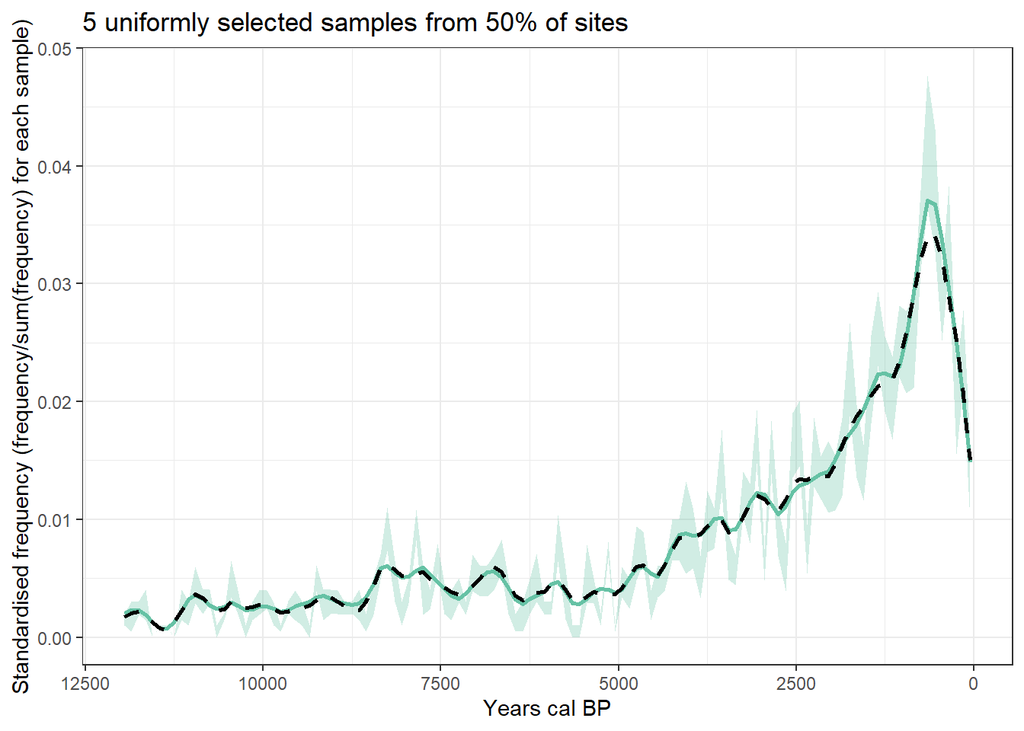

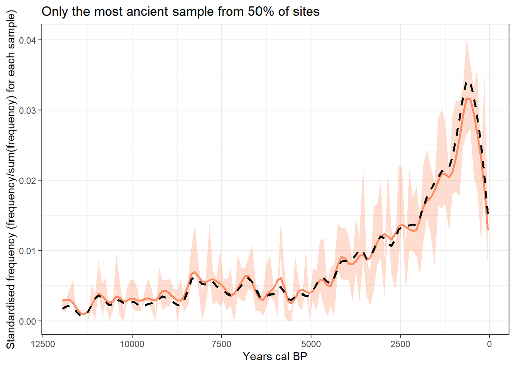

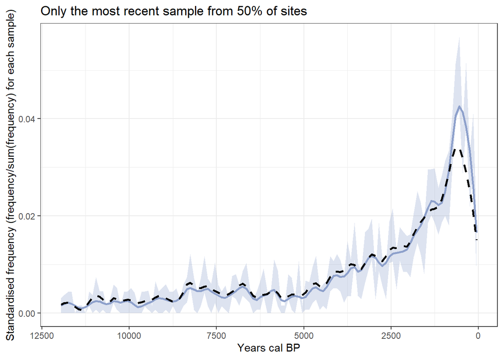

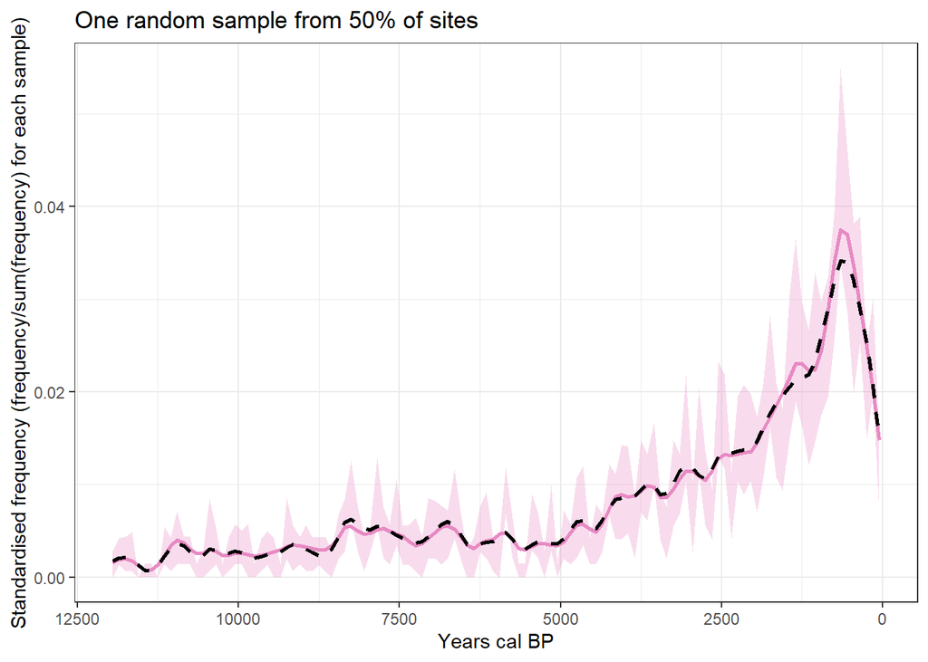

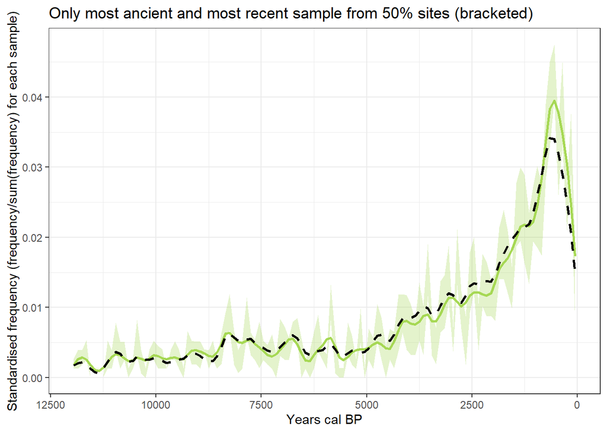

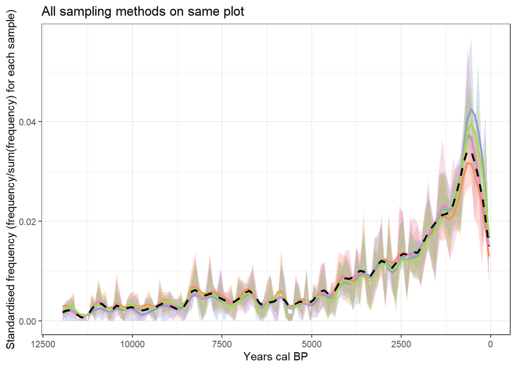